# Lab_05T

36-600

Fall 2022

To answer the questions below, it will help you to refer to Sections 10.3 and 10.5 of ISLR; it might also help you to refer to your previous lab work (and, as always, to Google).

## Question 1

Let’s create a fake data frame with three rows and three columns:

```r
(df <- data.frame(x=1:3,y=1:3,z=1:3))
```

```
##   x y z
## 1 1 1 1
## 2 2 2 2
## 3 3 3 3
```

Computing *by hand*, what is the Euclidean distances between the fake datum of row 1 and the fake data of rows 2 and 3? And what is the Euclidean distance between the fake data of rows 2 and 3?

```
FILL ME IN
Row 1 to row 2 = \sqrt(3)
Row 2 to row 3 = \sqrt(3)
```

## Question 2

Now compute the Euclidean distances using the `dist()` function. Show the output from this function. Does that output match your hand-computed quantities? If not, go back and think re-do your calculation in Question 1. If so, then you now have a sense as to what the “distance between two data points” is, in practice. Note the appearance of the output: the distances are stored in a lower-triangular matrix.

```r
# FILL ME IN
dist(df, method = "euclidean", diag = FALSE, upper = FALSE, p = 2)
```

```
##          1        2
## 2 1.732051
## 3 3.464102 1.732051
```

## Dataset 1

Here we import some data on stars either in, or in the same general direction as, the Draco Dwarf Galaxy.

```r
file.path <- "https://raw.githubusercontent.com/pefreeman/36-290/master/EXAMPLE_DATASETS/DRACO/draco_photometry.Rdata"
load(url(file.path))
df <- data.frame(ra,dec,velocity.los,log.g,mag.g,mag.r,mag.i)
rm(file.path,ra,dec,velocity.los,log.g,temperature,mag.u,mag.g,mag.r,mag.i,mag.z,metallicity,signal.noise)
```

```r
head(df,4)
```

```
##         ra      dec velocity.los log.g    mag.g    mag.r    mag.i
## 1 260.0115 57.81589       -294.1   3.7 19.70348 19.07734 18.81921
## 2 259.8737 57.71628       -205.1   3.1 20.11101 19.43237 19.13829
## 3 259.9352 57.79092       -282.1   4.5 20.26365 19.66915 19.40216
## 4 259.9352 57.79092       -283.7   2.1 20.26365 19.66915 19.40216
```

`df` is a data frame with 2778 rows and 7 columns. See this [README file](https://github.com/pefreeman/36-290/tree/master/EXAMPLE_DATASETS/DRACO) for a full description of the data and its variables.

## Question 3

Use `dplyr` functions to filter the data frame such that it only contains values of `dec` > 56, values of `ra` < 264, and values of `velocity.los` between -350 and -250. (Put a space between the “<” and the “-” when you filter on the latter velocity, otherwise `R` will see the assignment operator and act accordingly.) Mutate the data frame to have g-r and r-i colors (call them `gr` and `ri`), then delete the magnitudes and `velocity.los`. (Pro tip: you can “negatively select” columns by putting minus signs in front of the column names.) Save the resulting data frame as `df.new`.

```r
# FILL ME
suppressMessages(library(dplyr))
df %>% filter(.,dec>56 & ra<264 & velocity.los< -250 & velocity.los> -350) -> df
df %>%
  mutate(.,gr=mag.g-mag.r,ri=mag.r-mag.i) -> df.new
df.new %>%
  dplyr::select(.,-c(mag.g,mag.r,mag.i,velocity.los)) -> df.new
```

## Question 4

Use the `kmeans()` function to cluster the data in your data frame. Try different values for $k$, and finally display results for what *you* would choose as its optimal value. The default for `nstart` is 1; that should be increased to something larger…play with the values for this argument. Display the results using `ggpairs()`. Pass this argument to `ggpairs()`: `mapping=aes(color=factor(km.out$cluster))`, where `km.out` is the output from $K$-means, and `cluster` is the number of the cluster to which a datum has been assigned. Remember to `scale()` your data! Also, note that `kmeans()` utilizes random sampling, so you should absolutely set a random number seed immediately before calling `kmeans()` to ensure reproducibility!

```r
# FILL ME IN
suppressMessages(library(GGally))
set.seed(101)
km.out <- kmeans(scale(df.new),10,nstart=20)
```

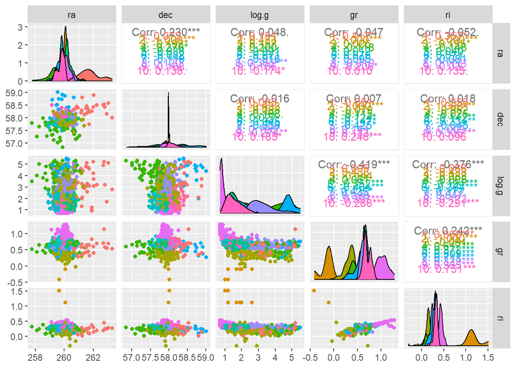

```r
# color <- km.out$cluster
ggpairs(df.new,mapping=aes(color=factor(km.out$cluster)))
```